# Introduction

### How has completion parameters changed since 2008

- Variation of completion parameters with time from 2008 - 2016. Fig. 2a seems to suggest an increasing trend in the number of stages used in completions between this period. There does not appear to be a systematic change in the length of lateral and perforated interval since 2008 (Fig. 2b). However, we see an increasing tendency towards perforating the lateral in the 9,000 ft. - 11,000 ft. range. As mentioned previously, the use of more than 5MM lbs of proppants started becoming popular after 2014. Most of the completions prior to 2012 utilized less than 100,000 bbls of total fluid and like the case of total proppants, the use of more than 100,000 bbls of total fluid became increasingly popular from 2013 and well into the downturn (Fig. 2d). This tendency to use more proppants and fluid volume may have led operators to complete fewer wells as a way of cutting overall cost during the downturn (fig. 2e).

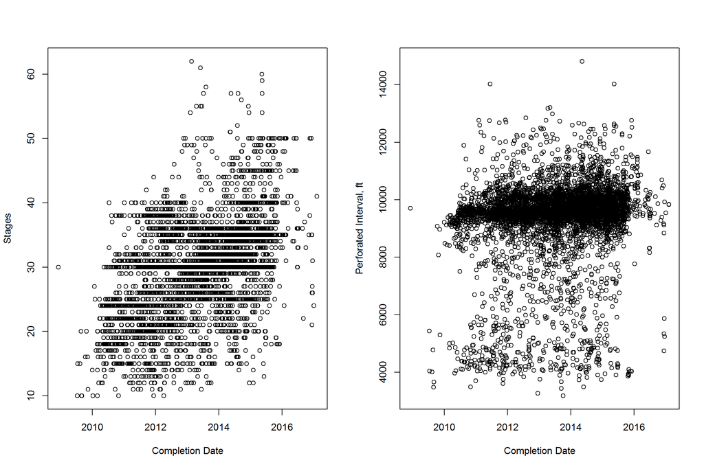

```
## [1] 574
```

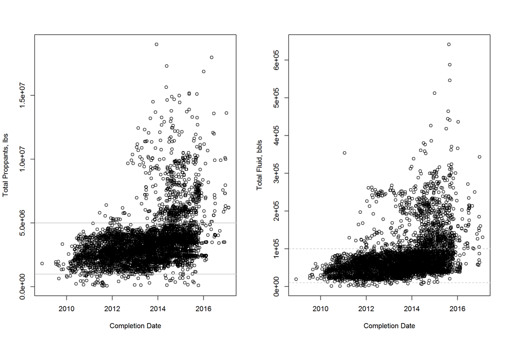

```
## [1] 780
```

```
## [1] 5311
```

### Looking at other well parameters

- Aggregate the number of wells completed by year.

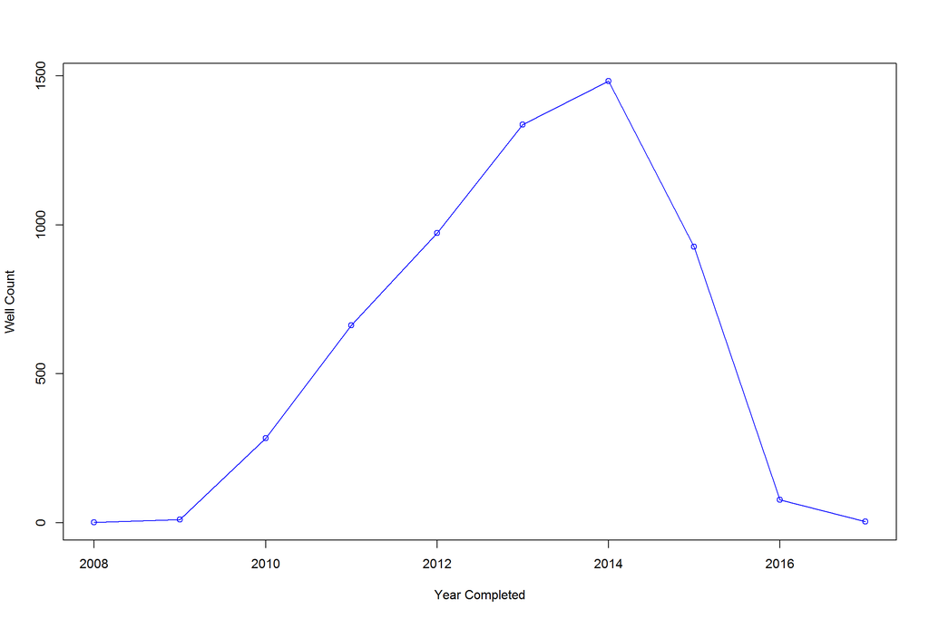

- Looking at injection rate and pressure

```
## [1]  2836.000  8366.275 12112.000
```

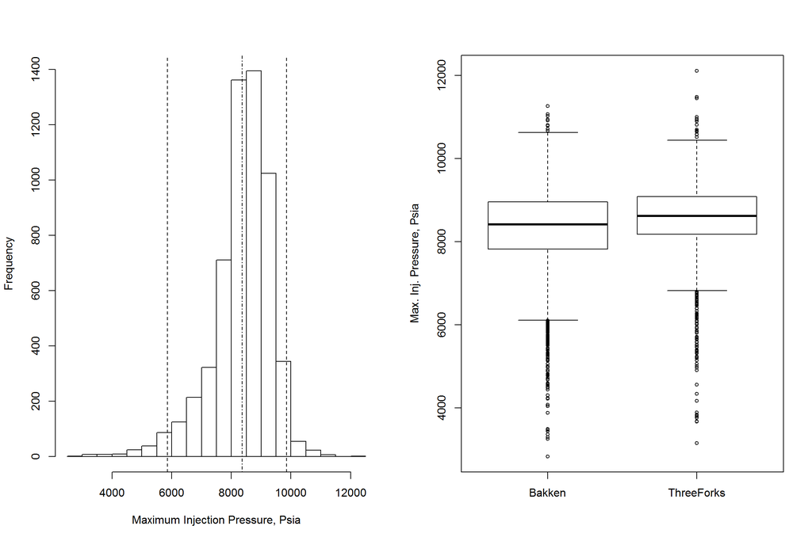

```
## [1]   8.10000  41.00137 153.40000
```

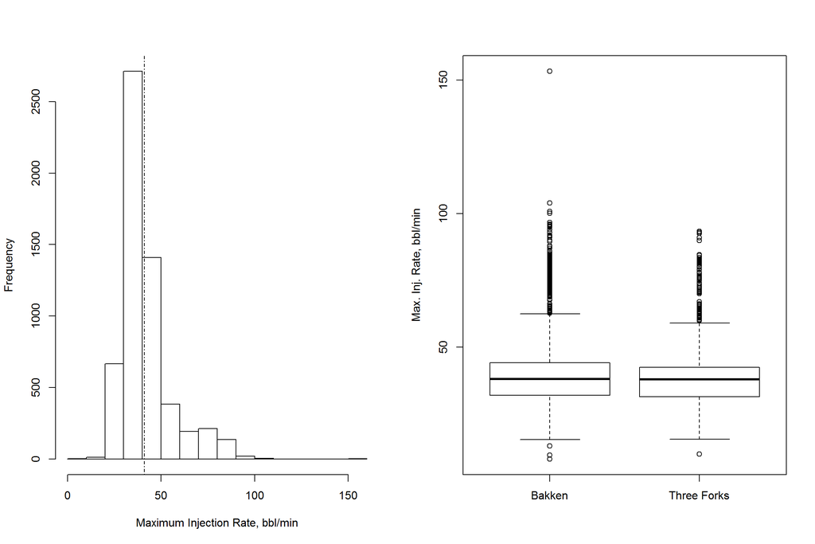

- Looking at TVD, TD, Peak Oil and 12 month oil

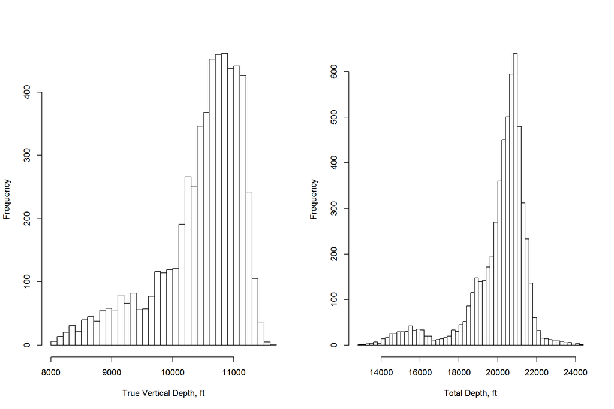

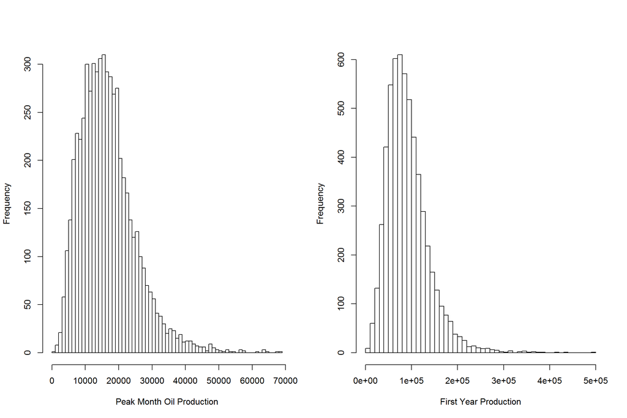

```
## [1] 91441.25
```